# Aula 11

Panosso AR & Perecin D

23-11-2022

# Diagnósticos da análise de variância

Todo delineamento experimental possui um modelo matemático que o representa, e deve ser levado em conta na análise de variância, **aceitando algumas hipóteses básicas necessárias para a validade da análise.**

No caso do $DIC$, por exemplo, o modelo matemático é definido como:

$$y_{ij}= \mu + \tau_i + \epsilon_{ij}$$
onde:

$y_{ij}$: é o valor observado na parcela que recebeu o tratamento *i* na repetição *j*;

$\mu$: é a média geral do experimento;

$\tau_i$ é o efeito devido ao tratamento *i* que foi aplicado à parcela;

$\epsilon_{ij}$ é o efeito dos fatores não controlados na parcela que recebeu o tratamento *i* na repetição *j*.

## Hipóteses básicas para aplicação da análise de variância

As hipóteses básicas que devemos admitir para tornar válida a aplicação da análise de variância são as seguintes:

1. **Aditividade**: Os efeitos dos fatores do modelo são aditivos.
2. **Independência**: Os erros (desvios) $\epsilon_{ij}$, devido aos efeitos de fatores não controlados ou acaso devem ser independentes.
3. **Homocedasticidade (homogeneidade de variâncias)**: Os erros (desvios) $\epsilon_{ij}$, devido ao acaso devem possuir variância comum $\sigma^2$
4. **Normalidade dos desvios**: Os erros ou desvios $\epsilon_{ij}$ devido ao acaso devem possuir distribuição normal de probabilidades.

Uma forma resumida de apresentar estas quatro pressuposições é apresentada a seguir:

$$\epsilon_{ij} \overset{iid}{\tilde{} }N(0,\sigma^2) \\$$

Quando as hipóteses básicas não são satisfeitas, como no caso mais frequente a **homocedasticidade**, deve-se utilizar uma transformação dos dados para contormar o problema.

## Transformações

### 1. Raiz Quadrada: $y'=\sqrt{y}$

Geralmente utilizada para **dados de contagem**, que frequentemente seguem a distribuição de *Poisson*, em que a **média e a variância são iguais**. Exemplo, número de ácaros por folha, número de frutos atacados, número de plantas doentes por parcela, etc. No caso de ocorrência de valores nulos ou baixos, recomenda-se $y'=\sqrt{y+0,5}$ ou $y'=\sqrt{y+1}$.

### 2. Arco Seno: $y'=arcoseno\sqrt{\frac{y}{100}}$

Recomendada para **dados de porcentagem**, proveniente de contagem, que geralmente seguem a distribuição **binomial**, como exemplo, $\%$ de plantas atacadas, $\%$ de germinação, etc.

### 3. Tranformação Potência

Quando é constatada uma certa **proporcionalidade entre as médias e os desvios padrões** dos tratamentos. Exemplo: No caso de contagem de insetos, se a população é numerosa, as contagens serão altas para a testemunha e para os tratamentos que não controlam a praga, enquanto que, para os tratamentos que controlam a praga, a amplitude de variação será baixa.

Pode-se verificar isso pelo diagrama de dispersão, visualizando a reta $y = a + b x$, plotando-se: $x = log(média)$ versus $y = log(desvio padrão)$.

- Se $b=2,0$, a transformação adequada é a recíproca: $y' = y^{-1}$;
- Se $b=1,5$, a transformação adequada é a recíproca da raiz quadrada: $y' = y^{-1/2}$;
- Se $b=1,0$, a transformação adequada é a logarítmica : $y' =log(y)$;
- Se $b=0,5$, a transformação adequada é a raiz quadrada : $y' = y^{1/2}$.
- Se $b=0$, não faça transformação.

#### Exemplo 01

Para esse exemplo, vamos os dados de crescimendo de uma cultura em $5$ tempos distintos, disponível no arquivo aula11.xlsx, planilha denominada “Crescimento”.

#### Carregando os pacotes necessários.

```r
library(tidyverse)
library(readxl)
library(janitor)
library(nortest)
library(lawstat)
library(MASS)
```

#### Lendo o banco de dados e criando um resumo rápido.

Pode ser acessado em aula11.xlsx disponível na pasta *data* do projeto.

```r
dados <- read_xlsx("/data/aula11.xlsx",
                   sheet = "Crescimento") %>%
  clean_names()
```

```r
glimpse(dados)
```

```
## Rows: 20
## Columns: 2
## $ tempo <dbl> 1, 1, 1, 1, 2, 2, 2, 2, 3, 3, 3, 3, 4, 4, 4, 4, 5, 5, 5, 5
## $ resp  <dbl> 2, 2, 3, 2, 5, 3, 7, 7, 15, 10, 20, 16, 30, 23, 37, 31, 33, 25, ~
```

#### Gráfico da resposta em função do tempo.

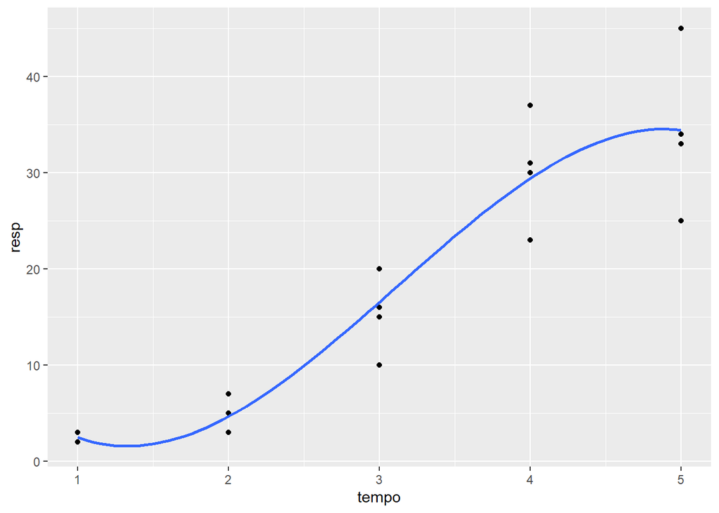

```r
dados %>%
  ggplot(aes(x=tempo, y=resp)) +
  geom_point() +
  geom_smooth(method = "lm", se=FALSE,
              formula = y ~ poly(x, 3)
              )
```

### Encontrando a equação da curva de ajuste.

```r
lm(resp ~ tempo + tempo2 + tempo3,
   data = dados %>%
     mutate(
       tempo2=tempo^2,
       tempo3=tempo^3,
     )) %>% summary()
```

```
##
## Call:
## lm(formula = resp ~ tempo + tempo2 + tempo3, data = dados %>%
##     mutate(tempo2 = tempo^2, tempo3 = tempo^3, ))
##
## Residuals:
##     Min      1Q  Median      3Q     Max
## -9.4643 -1.4821 -0.4643  1.7946 10.5357
##
## Coefficients:
##             Estimate Std. Error t value Pr(>|t|)
## (Intercept)  18.7500    11.9373   1.571   0.1358
## tempo       -28.4345    15.6039  -1.822   0.0872 .
## tempo2       13.6071     5.7916   2.349   0.0320 *
## tempo3       -1.4583     0.6395  -2.281   0.0366 *
## ---
## Signif. codes:  0 '***' 0.001 '**' 0.01 '*' 0.05 '.' 0.1 ' ' 1
##
## Residual standard error: 4.853 on 16 degrees of freedom
## Multiple R-squared:  0.8971, Adjusted R-squared:  0.8778
## F-statistic: 46.51 on 3 and 16 DF,  p-value: 3.994e-08
```

#### Agora precisamos da tabela da média e do desvio padrão.

```r
dados %>%
  group_by(tempo) %>%
  summarise(
    media = mean(resp),
    dp = sd(resp),
    Log_media = log10(media),
    Log_dp = log10(dp)
  )
```

```
## # A tibble: 5 x 5
##   tempo media    dp Log_media Log_dp
##   <dbl> <dbl> <dbl>     <dbl>  <dbl>
## 1     1  2.25  0.5      0.352 -0.301
## 2     2  5.5   1.91     0.740  0.282
## 3     3 15.2   4.11     1.18   0.614
## 4     4 30.2   5.74     1.48   0.759
## 5     5 34.2   8.22     1.53   0.915
```

#### De posse da tabela, vamos fazer o gráfico de Log_dp versus Log_media.

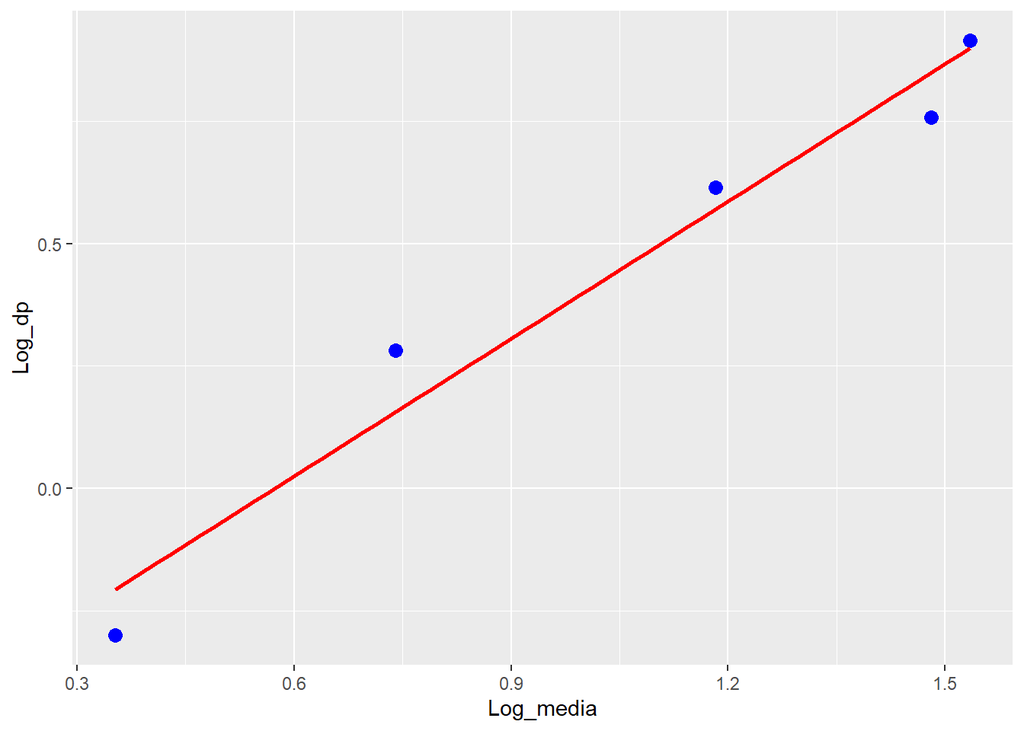

```r
dados %>%
  group_by(tempo) %>%
  summarise(
    media = mean(resp),
    dp = sd(resp),
    Log_media = log10(media),
    Log_dp = log10(dp)
  ) %>%
  ggplot(aes(x=Log_media, y=Log_dp)) +
  geom_point(size=3, shape=16, color="blue") +
  geom_smooth(method="lm", se=FALSE, color="red")
```

```r
lm(Log_dp ~ Log_media,
   data= dados %>%
  group_by(tempo) %>%
  summarise(
    media = mean(resp),
    dp = sd(resp),
    Log_media = log10(media),
    Log_dp = log10(dp)
  )) %>% summary()
```

```
##
## Call:
## lm(formula = Log_dp ~ Log_media, data = dados %>% group_by(tempo) %>%
##     summarise(media = mean(resp), dp = sd(resp), Log_media = log10(media),
##         Log_dp = log10(dp)))
##
## Residuals:
##        1        2        3        4        5
## -0.09343  0.12612  0.04326 -0.09082  0.01487
##
## Coefficients:
##             Estimate Std. Error t value Pr(>|t|)
## (Intercept)  -0.5375     0.1230  -4.371  0.02216 *
## Log_media     0.9367     0.1069   8.764  0.00313 **
## ---
## Signif. codes:  0 '***' 0.001 '**' 0.01 '*' 0.05 '.' 0.1 ' ' 1
##
## Residual standard error: 0.108 on 3 degrees of freedom
## Multiple R-squared:  0.9624, Adjusted R-squared:  0.9499
## F-statistic: 76.82 on 1 and 3 DF,  p-value: 0.003128
```

A transformação é aproximadamente Log.

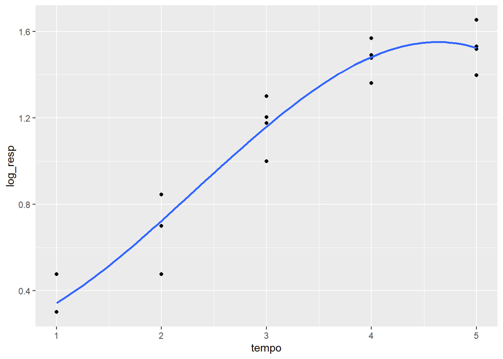

```r
dados %>%
  mutate(log_resp = log10(resp)) %>%
  ggplot(aes(x=tempo, y=log_resp)) +
  geom_point() +
  geom_smooth(method = "lm", se=FALSE,
              formula = y ~ poly(x, 3)
              )
```

### Contruir o boxplot

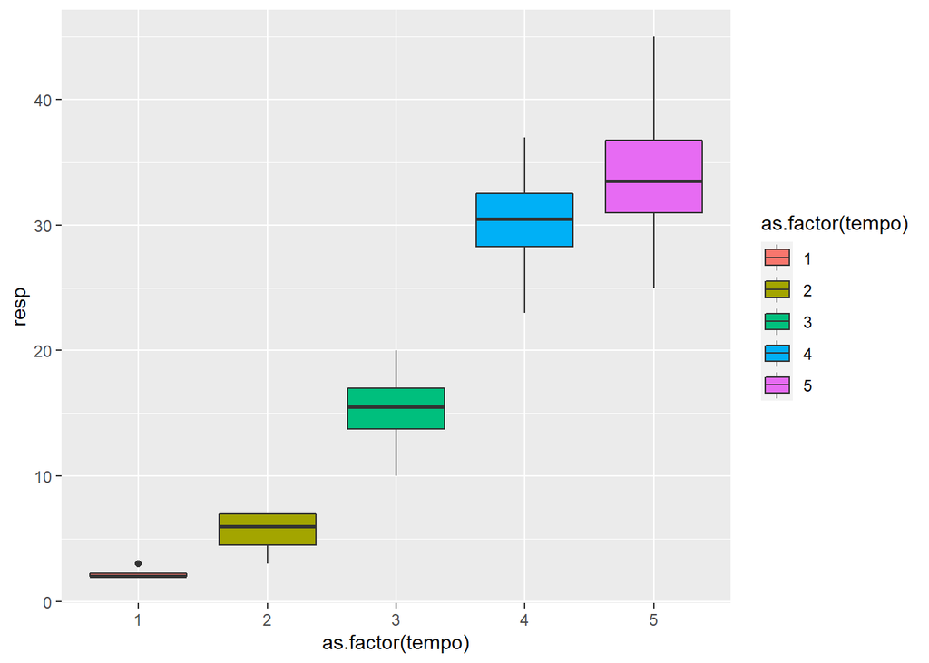

```r
dados %>%
  group_by(tempo) %>%
  ggplot(aes(y=resp, x=as.factor(tempo),
             fill=as.factor(tempo))) +
  geom_boxplot()
```

```r
lm(log_resp ~ tempo + tempo2 + tempo3,
   data = dados %>%
     mutate(
       log_resp = log10(resp),
       tempo2=tempo^2,
       tempo3=tempo^3,
     )) %>% summary()
```

```
##
## Call:
## lm(formula = log_resp ~ tempo + tempo2 + tempo3, data = dados %>%
##     mutate(log_resp = log10(resp), tempo2 = tempo^2, tempo3 = tempo^3,
##         ))
##
## Residuals:
##       Min        1Q    Median        3Q       Max
## -0.246736 -0.042201  0.001623  0.095045  0.141648
##
## Coefficients:
##              Estimate Std. Error t value Pr(>|t|)
## (Intercept)  0.185417   0.286181   0.648   0.5262
## tempo       -0.009564   0.374082  -0.026   0.9799
## tempo2       0.195363   0.138846   1.407   0.1785
## tempo3      -0.027986   0.015330  -1.826   0.0866 .
## ---
## Signif. codes:  0 '***' 0.001 '**' 0.01 '*' 0.05 '.' 0.1 ' ' 1
##
## Residual standard error: 0.1163 on 16 degrees of freedom
## Multiple R-squared:   0.95,  Adjusted R-squared:  0.9406
## F-statistic: 101.3 on 3 and 16 DF,  p-value: 1.278e-10
```

**OBS** com a transformação logarítmica (b similar a 1) há homogenenidade das variâncias e menor ponto de inflexão.

### 4. Tranformação Box-Cox

A transformação de Box-Cox é dada pela seguinte fórmula:

$$W_i = Y_i^\lambda, \text{ se } \lambda \neq 0 \\
W_i = Ln(Y_i), \text{ se } \lambda = 0 \\
W_i = Y_i, \text{ se } \lambda = 1$$
onde $Y_i$ é um valor de dados original e $\lambda$ é o parâmetro para a transformação. Observe que $\lambda = 1.0$ **NÂO TRANSFORMAR**.

$$\begin{aligned}
\lambda &= -1.0, \text{ } x_i(\lambda) = \frac{1}{x_i} \\
\lambda &= -0.5, \text{ } x_i(\lambda) = \frac{1}{\sqrt{x_i}} \\
\lambda &= 0.0, \text{ } x_i(\lambda) = Ln(x_i) \\
\lambda &= 0.5, \text{ } x_i(\lambda) = \sqrt{x_i} \\
\lambda &= 2.0, \text{ } x_i(\lambda) = x_i^2
\end{aligned}$$
A utilização da transformação Box-Cox, por ser uma transformação do tipo potência, não detecta alguns tipos de transformação classicamente utilizados, por exemplo “arco seno raiz(porcentagem/100)”, usado para porcentagens binomiais.

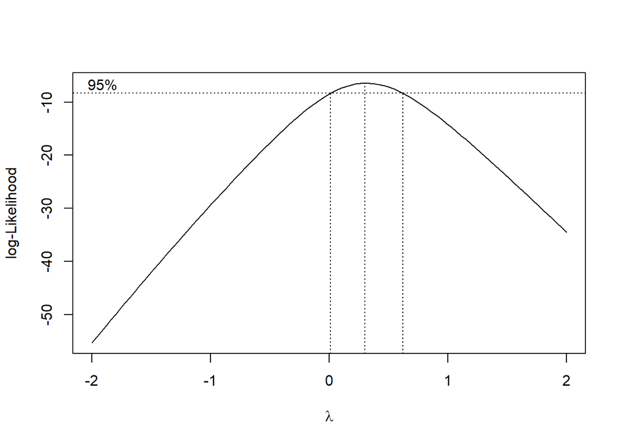

```r
mod <- lm(resp ~ tempo,
          data = dados)
boxcox(mod)
```

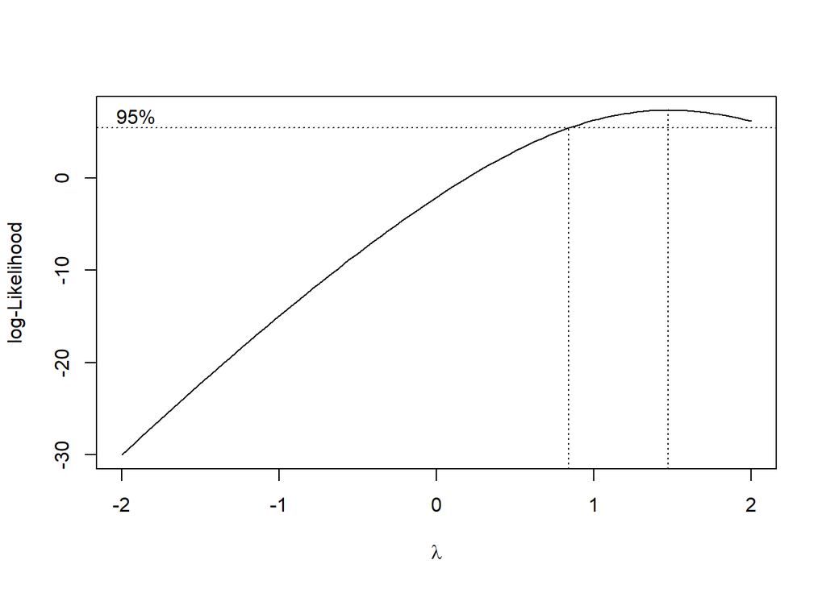

```r
mod2 <- lm(log(resp) ~ tempo,
          data = dados)
boxcox(mod2)
```

### Construir o boxplot

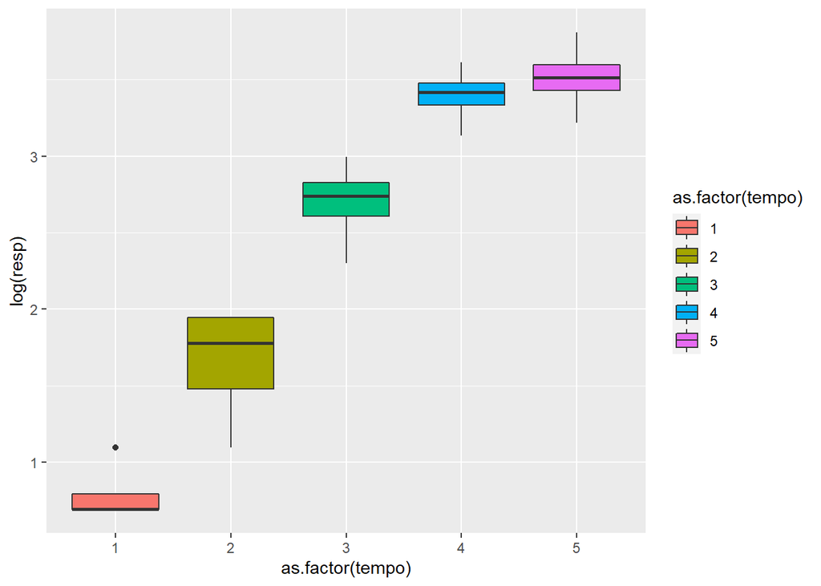

```r
dados %>%
  group_by(tempo) %>%
  ggplot(aes(y=log(resp), x=as.factor(tempo),
             fill=as.factor(tempo))) +
  geom_boxplot()
```

### Realizar o teste de normalidade dos resíduos do modelo, apresentando o histograma dos mesmos

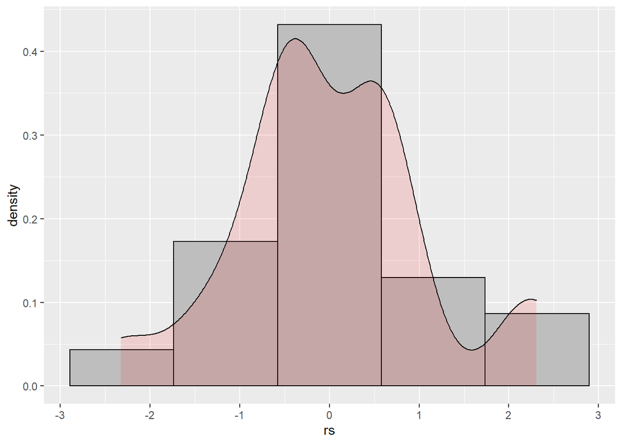

```r
dados %>%
  mutate(
    rs = rstudent(lm(resp ~ tempo))
  ) %>%
  ggplot(aes(x=rs, y=..density..)) +
  geom_histogram(bins=5, color="black",fill="gray") +
  geom_density(fill="red", alpha=.12)
```

```r
rs <- dados %>%
  mutate(
    rs = rstudent(lm(resp ~ tempo))
  ) %>% pull(rs)
shapiro.test(rs)
```

```
##
##  Shapiro-Wilk normality test
##
## data:  rs
## W = 0.95469, p-value = 0.444
```

```r
ad.test(rs)
```

```
##
##  Anderson-Darling normality test
##
## data:  rs
## A = 0.45151, p-value = 0.2457
```

```r
cvm.test(rs)
```

```
##
##  Cramer-von Mises normality test
##
## data:  rs
## W = 0.073413, p-value = 0.2389
```

```r
lillie.test(rs)
```

```
##
##  Lilliefors (Kolmogorov-Smirnov) normality test
##
## data:  rs
## D = 0.14257, p-value = 0.3556
```

### Construir o qqplot

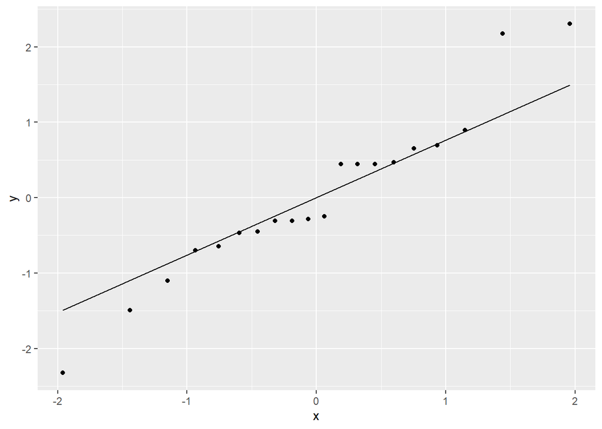

```r
dados %>%
  mutate(
    rs = rstudent(lm(resp ~ tempo))
  ) %>%
  ggplot(aes(sample = rs)) +
  stat_qq() +
  stat_qq_line()
```

### Realizar os testes de homocedasticidade

#### Teste de Brown & Forsythe

```r
levene.test(dados$resp,dados$tempo)
```

```
##
##  Modified robust Brown-Forsythe Levene-type test based on the absolute
##  deviations from the median
##
## data:  dados$resp
## Test Statistic = 1.3935, p-value = 0.2835
```

### Teste de Levene

```r
levene.test(dados$resp,dados$tempo, location = "mean")
```

```
##
##  Classical Levene's test based on the absolute deviations from the mean
##  ( none not applied because the location is not set to median )
##
## data:  dados$resp
## Test Statistic = 1.4858, p-value = 0.2559
```

Teste de Bartlet

```r
bartlett.test(log(dados$resp),dados$tempo)
```

```
##
##  Bartlett test of homogeneity of variances
##
## data:  log(dados$resp) and dados$tempo
## Bartlett's K-squared = 1.9691, df = 4, p-value = 0.7414
```

### Realizar o estudo de ‘outliers’

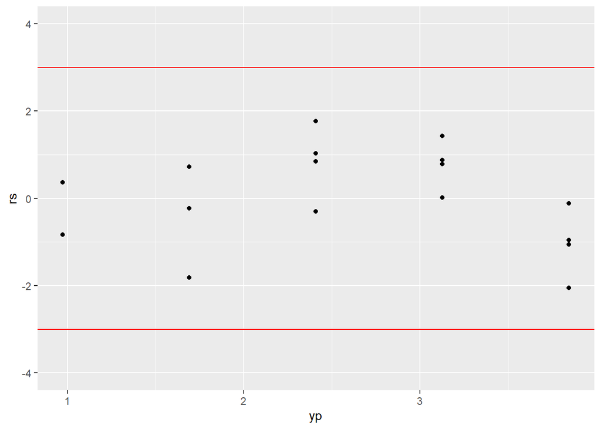

```r
dados %>%
  mutate(
    rs = lm(log(resp) ~tempo) %>% rstudent,
    yp = lm(log(resp) ~tempo) %>% predict()
  ) %>%
  ggplot(aes(x=yp,y=rs)) +
  geom_point() +
  coord_cartesian(ylim=c(-4,4)) +
  geom_hline(yintercept = c(-3,3), color="red")
```

#### Exercício

Realizar os diagnósticos e as transformações, se necessário do dados referentes a:

- ENSAIO COM CIGARRINHAS (LEILA DINARDO MIRANDA IAC)
- FATOR A= CULTIVARES (18) DE CANA
- FATOR B= COM OU SEM CIGARRINHAS
- Z=MEDIDA DA CLOROFILA
- Y=PESO DAS PLANTAS

```
## Rows: 179
## Columns: 6
## $ tr <chr> "1", "2", "1", "2", "1", "2", "1", "1", "2", "3", "4", "3", "4", "3~
## $ fa <chr> "C9", "C9", "C9", "C9", "C9", "C9", "C9", "C9", "C9", "CTC2", "CTC2~
## $ fb <chr> "COM", "SEM", "COM", "SEM", "COM", "SEM", "COM", "COM", "SEM", "COM~
## $ bl <dbl> 1, 1, 3, 3, 4, 4, 5, 2, 2, 1, 1, 2, 2, 3, 3, 4, 4, 5, 5, 1, 1, 2, 2~
## $ z  <dbl> 112.4, 148.2, 144.3, 160.1, 140.4, 154.8, 157.1, 139.0, 149.0, 21.4~
## $ y  <dbl> 355.7, 379.9, 351.1, 381.8, 360.3, 366.7, 363.3, 346.8, 353.8, 42.8~
```

```r
library(ExpDes.pt)
library(patchwork)
library(tidyverse)
library(agricolae)
library(readxl)
library(nlme)
library(lme4)
library(janitor)
```

```r
# entrada de dados
dados <- read_xlsx("data/aula11.xlsx",
                   sheet = "Cigarrinha") %>%
  clean_names() %>%
  rename(cultivar = fa, cigarrinha = fb) %>%
  mutate_at(vars(tr, cultivar, cigarrinha), as_factor)
glimpse(dados)
```

```
## Rows: 179
## Columns: 6
## $ tr         <fct> "1", "2", "1", "2", "1", "2", "1", "1", "2", "3", "4", "3",~
## $ cultivar   <fct> C9, C9, C9, C9, C9, C9, C9, C9, C9, CTC2, CTC2, CTC2, CTC2,~
## $ cigarrinha <fct> COM, SEM, COM, SEM, COM, SEM, COM, COM, SEM, COM, SEM, COM,~
## $ bl         <dbl> 1, 1, 3, 3, 4, 4, 5, 2, 2, 1, 1, 2, 2, 3, 3, 4, 4, 5, 5, 1,~
## $ z          <dbl> 112.4, 148.2, 144.3, 160.1, 140.4, 154.8, 157.1, 139.0, 149~
## $ y          <dbl> 355.7, 379.9, 351.1, 381.8, 360.3, 366.7, 363.3, 346.8, 353~
```

### Análise Diagnóstico Clorofila

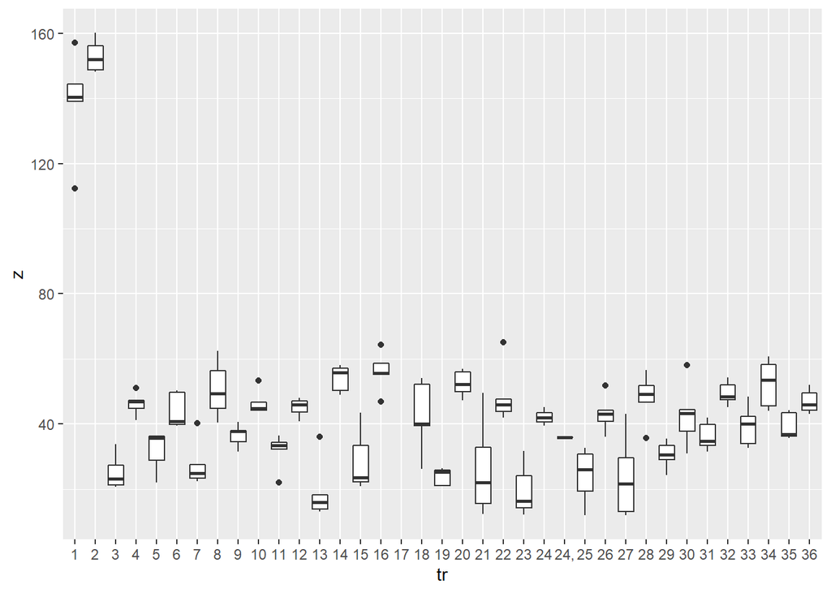

```r
dados %>%
  group_by(tr) %>%
  ggplot(aes(y=z, x=tr)) +
  geom_boxplot()
```

```r
# Teste de Homocedasticidade
library(lawstat)
levene.test(dados$z,dados$tr)
```

```
##
##  Modified robust Brown-Forsythe Levene-type test based on the absolute
##  deviations from the median
##
## data:  dados$z
## Test Statistic = 0.92825, p-value = 0.5821
```

```r
levene.test(dados$z,dados$tr,
            location = "mean")
```

```
##
##  Classical Levene's test based on the absolute deviations from the mean
##  ( none not applied because the location is not set to median )
##
## data:  dados$z
## Test Statistic = 1.7444, p-value = 0.01615
```

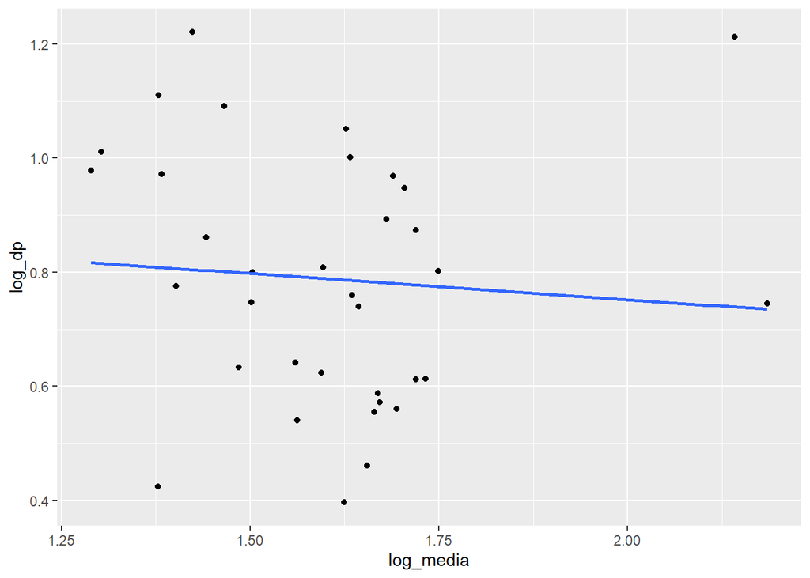

```r
# testar as transformações potência
dados %>%
  group_by(tr) %>%
  summarise(
    media = mean(z, na.rm=TRUE),
    dp = sd(z, na.rm=TRUE),
    log_media = log10(media),
    log_dp = log10(dp)
  ) %>%
  ggplot(aes(x=log_media, y=log_dp)) +
  geom_point()+
  geom_smooth(method = "lm", se=FALSE)
```

```r
# Análise de ajuste linear entre log_dp vrsus log_media
lm(log_dp ~ log_media,
   data=dados %>%
     group_by(tr) %>%
     summarise(
       media = mean(z, na.rm=TRUE),
       dp = sd(z, na.rm=TRUE),
       log_media = log10(media),
       log_dp = log10(dp)
     )) %>%  summary
```

```
##
## Call:
## lm(formula = log_dp ~ log_media, data = dados %>% group_by(tr) %>%
##     summarise(media = mean(z, na.rm = TRUE), dp = sd(z, na.rm = TRUE),
##         log_media = log10(media), log_dp = log10(dp)))
##
## Residuals:
##      Min       1Q   Median       3Q      Max
## -0.39009 -0.16605  0.00202  0.16612  0.47365
##
## Coefficients:
##             Estimate Std. Error t value Pr(>|t|)
## (Intercept)  0.93498    0.32507   2.876    0.007 **
## log_media   -0.09154    0.20140  -0.455    0.652
## ---
## Signif. codes:  0 '***' 0.001 '**' 0.01 '*' 0.05 '.' 0.1 ' ' 1
##
## Residual standard error: 0.2243 on 33 degrees of freedom
##   (2 observations deleted due to missingness)
## Multiple R-squared:  0.006221,   Adjusted R-squared:  -0.02389
## F-statistic: 0.2066 on 1 and 33 DF,  p-value: 0.6524
```

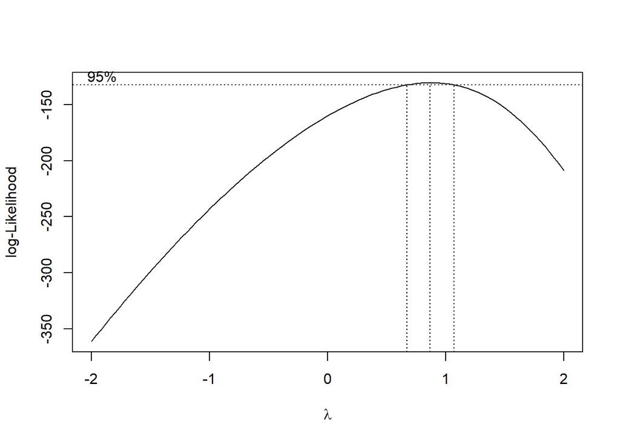

```r
### Aplicação da transformação de Box-Cox
mod <- aov(z ~ bl + tr,
           data=dados)
library(MASS)
boxcox(mod)
```

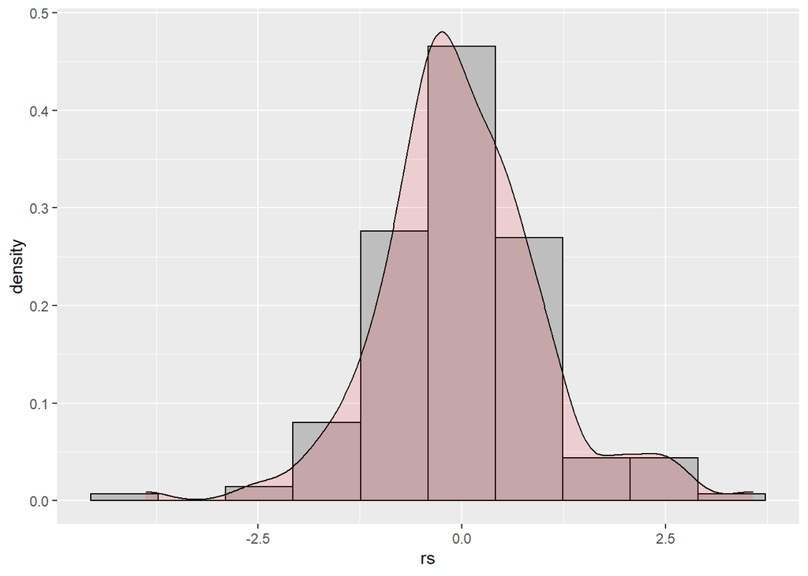

```r
## teste de normalidade dos resíduos
dados %>%
  drop_na() %>%
  mutate(
    rs = rstudent(aov(z ~ tr + bl))
  ) %>%
  ggplot(aes(x=rs, y=..density..)) +
  geom_histogram(bins=10, color="black",fill="gray") +
  geom_density(fill="red", alpha=.12)
```

```r
# Extraindo os resíduos
rs <- dados %>%
  drop_na() %>%
  mutate(
    rs = rstudent(aov(z ~ bl + tr))
  ) %>% pull(rs)
shapiro.test(rs)
```

```
##
##  Shapiro-Wilk normality test
##
## data:  rs
## W = 0.96929, p-value = 0.0009252
```

```r
library(nortest)
ad.test(rs)
```

```
##
##  Anderson-Darling normality test
##
## data:  rs
## A = 1.4572, p-value = 0.0008903
```

```r
cvm.test(rs)
```

```
##
##  Cramer-von Mises normality test
##
## data:  rs
## W = 0.22743, p-value = 0.0024
```

```r
lillie.test(rs)
```

```
##
##  Lilliefors (Kolmogorov-Smirnov) normality test
##
## data:  rs
## D = 0.072138, p-value = 0.03368
```

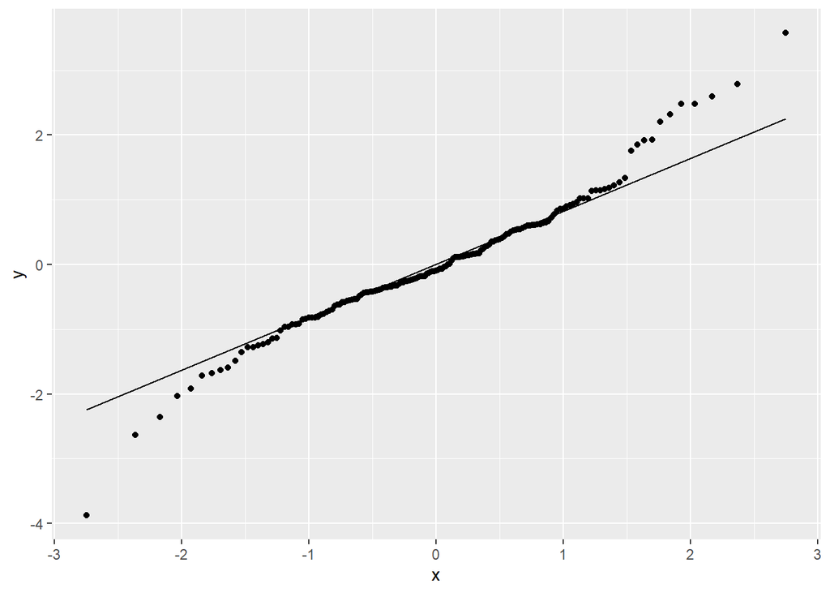

```r
## construir o qqplot
dados %>%
  drop_na() %>%
  mutate(
    rs = rstudent(aov(z ~ bl + tr))
  ) %>%
  ggplot(aes(sample = rs)) +
  stat_qq() +
  stat_qq_line()
```

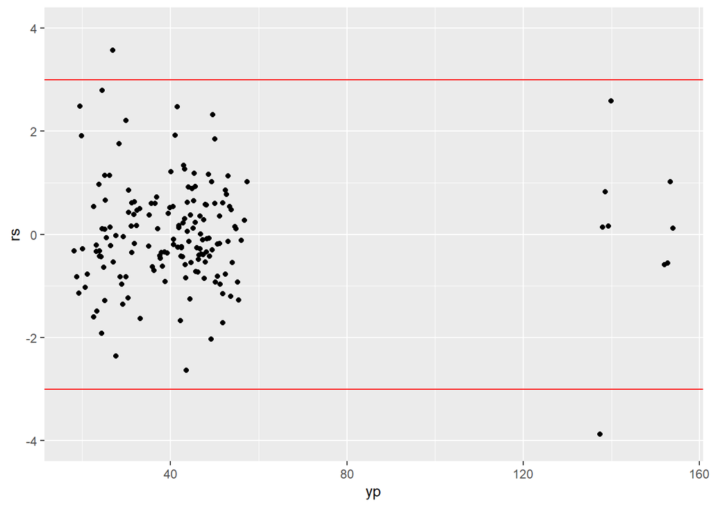

```r
# Estudo dos outliers

dados %>%
  drop_na() %>%
  mutate(
    rs = aov(z ~ tr + bl) %>% rstudent,
    yp = aov(z ~ tr + bl) %>% predict()
  ) %>%
  ggplot(aes(x=yp,y=rs)) +
  geom_point() +
  coord_cartesian(ylim=c(-4,4)) +
  geom_hline(yintercept = c(-3,3), color="red")
```

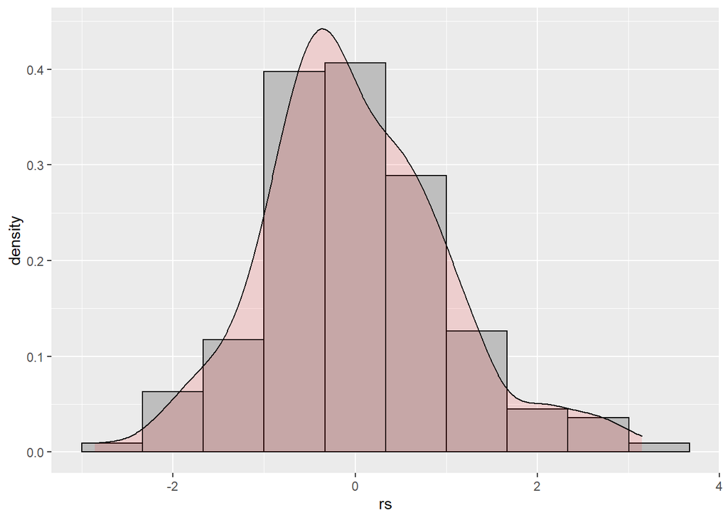

```r
## identificando os outliers

dados <- dados %>%
  drop_na() %>%
  mutate(
    rs = aov(z ~ tr + bl) %>% rstudent,
    yp = aov(z ~ tr + bl) %>% predict()
  ) %>%
  mutate(
    z2 = ifelse(rs < -3 | rs > 3, yp, z)
  )

### refazendo a análise de normalidade dos
### com Z2
## teste de normalidade dos resíduos
dados %>%
  drop_na() %>%
  mutate(
    rs = rstudent(aov(z2 ~ tr + bl))
  ) %>%
  ggplot(aes(x=rs, y=..density..)) +
  geom_histogram(bins=10, color="black",fill="gray") +
  geom_density(fill="red", alpha=.12)
```

```r
# Extraindo os resíduos
rs <- dados %>%
  drop_na() %>%
  mutate(
    rs = rstudent(aov(z2 ~ bl + tr))
  ) %>% pull(rs)
shapiro.test(rs)
```

```
##
##  Shapiro-Wilk normality test
##
## data:  rs
## W = 0.98186, p-value = 0.02866
```

```r
library(nortest)
ad.test(rs)
```

```
##
##  Anderson-Darling normality test
##
## data:  rs
## A = 0.93753, p-value = 0.01713
```

```r
cvm.test(rs)
```

```
##
##  Cramer-von Mises normality test
##
## data:  rs
## W = 0.15033, p-value = 0.02328
```

```r
lillie.test(rs)
```

```
##
##  Lilliefors (Kolmogorov-Smirnov) normality test
##
## data:  rs
## D = 0.067132, p-value = 0.0651
```

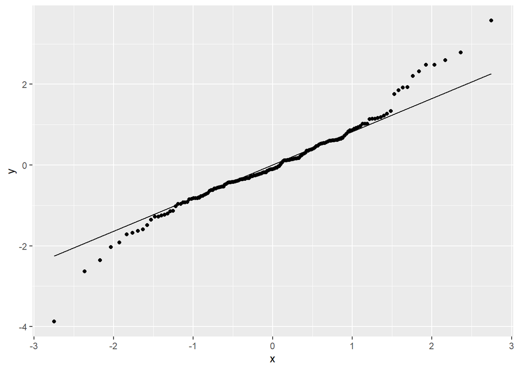

```r
## construir o qqplot
dados %>%
  drop_na() %>%
  mutate(
    rs = rstudent(aov(z ~ bl + tr))
  ) %>%
  ggplot(aes(sample = rs)) +
  stat_qq() +
  stat_qq_line()
```

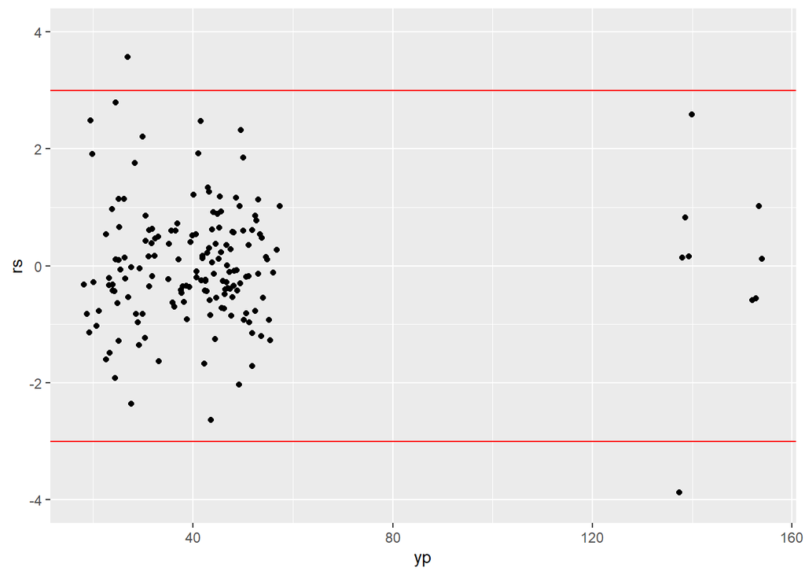

```r
# Estudo dos outliers

dados %>%
  drop_na() %>%
  mutate(
    rs = aov(z ~ tr + bl) %>% rstudent,
    yp = aov(z ~ tr + bl) %>% predict()
  ) %>%
  ggplot(aes(x=yp,y=rs)) +
  geom_point() +
  coord_cartesian(ylim=c(-4,4)) +
  geom_hline(yintercept = c(-3,3), color="red")
```

```r
## Análise de variância
mod <- aov(z2 ~ bl + cultivar*cigarrinha,
           data = dados)
anova(mod)
```

```
## Analysis of Variance Table
##
## Response: z2
##                      Df Sum Sq Mean Sq  F value    Pr(>F)
## bl                    1     16    15.6   0.3288 0.5673380
## cultivar             17 102730  6042.9 127.0513 < 2.2e-16 ***
## cigarrinha            1  13623 13623.2 286.4247 < 2.2e-16 ***
## cultivar:cigarrinha  16   2430   151.9   3.1932 0.0001239 ***
## Residuals           130   6183    47.6
## ---
## Signif. codes:  0 '***' 0.001 '**' 0.01 '*' 0.05 '.' 0.1 ' ' 1
```

### Análise Diagnóstico - Peso Planta

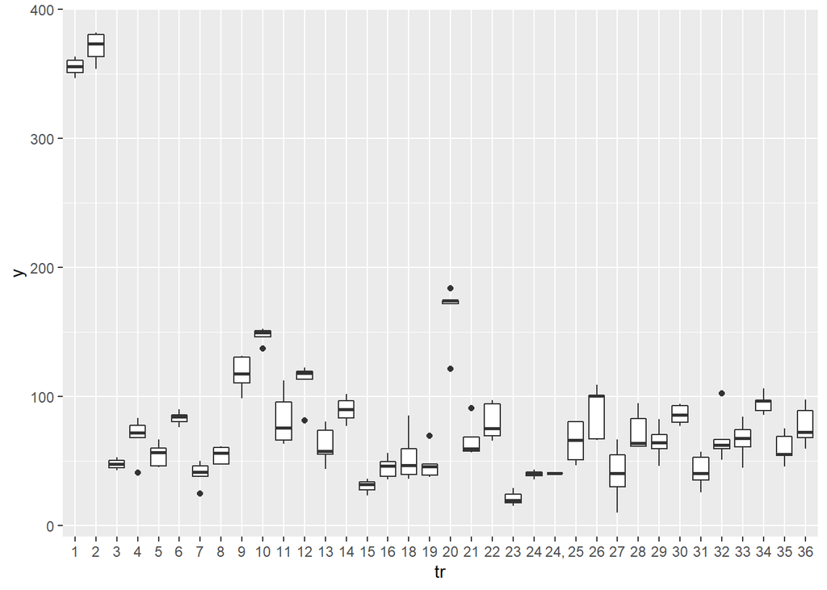

```r
dados %>%
  group_by(tr) %>%
  ggplot(aes(y=y, x=tr)) +
  geom_boxplot()
```

```r
# Teste de Homocedasticidade
library(lawstat)
levene.test(dados$y,dados$tr)
```

```
##
##  Modified robust Brown-Forsythe Levene-type test based on the absolute
##  deviations from the median
##
## data:  dados$y
## Test Statistic = 0.66056, p-value = 0.9224
```

```r
levene.test(dados$y,dados$tr,
            location = "mean")
```

```
##
##  Classical Levene's test based on the absolute deviations from the mean
##  ( none not applied because the location is not set to median )
##
## data:  dados$y
## Test Statistic = 1.6867, p-value = 0.0187
```

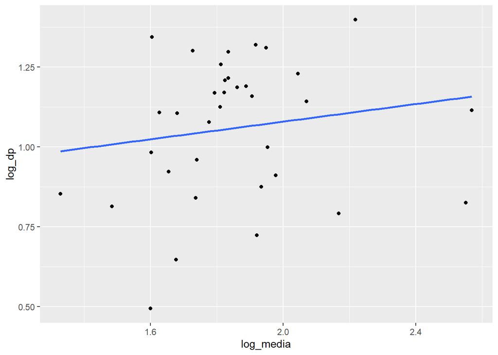

```r
# testar as transformações potência
dados %>%
  group_by(tr) %>%
  summarise(
    media = mean(y, na.rm=TRUE),
    dp = sd(y, na.rm=TRUE),
    log_media = log10(media),
    log_dp = log10(dp)
  ) %>%
  ggplot(aes(x=log_media, y=log_dp)) +
  geom_point()+
  geom_smooth(method = "lm", se=FALSE)
```

```r
# Análise de ajuste linear entre log_dp vrsus log_media
lm(log_dp ~ log_media,
   data=dados %>%
     group_by(tr) %>%
     summarise(
       media = mean(y, na.rm=TRUE),
       dp = sd(y, na.rm=TRUE),
       log_media = log10(media),
       log_dp = log10(dp)
     )) %>%  summary
```

```
##
## Call:
## lm(formula = log_dp ~ log_media, data = dados %>% group_by(tr) %>%
##     summarise(media = mean(y, na.rm = TRUE), dp = sd(y, na.rm = TRUE),
##         log_media = log10(media), log_dp = log10(dp)))
##
## Residuals:
##      Min       1Q   Median       3Q      Max
## -0.53009 -0.14954  0.07079  0.14849  0.31854
##
## Coefficients:
##             Estimate Std. Error t value Pr(>|t|)
## (Intercept)   0.8034     0.2771   2.900  0.00659 **
## log_media     0.1378     0.1481   0.931  0.35875
## ---
## Signif. codes:  0 '***' 0.001 '**' 0.01 '*' 0.05 '.' 0.1 ' ' 1
##
## Residual standard error: 0.2185 on 33 degrees of freedom
##   (1 observation deleted due to missingness)
## Multiple R-squared:  0.02558,    Adjusted R-squared:  -0.003949
## F-statistic: 0.8663 on 1 and 33 DF,  p-value: 0.3587
```

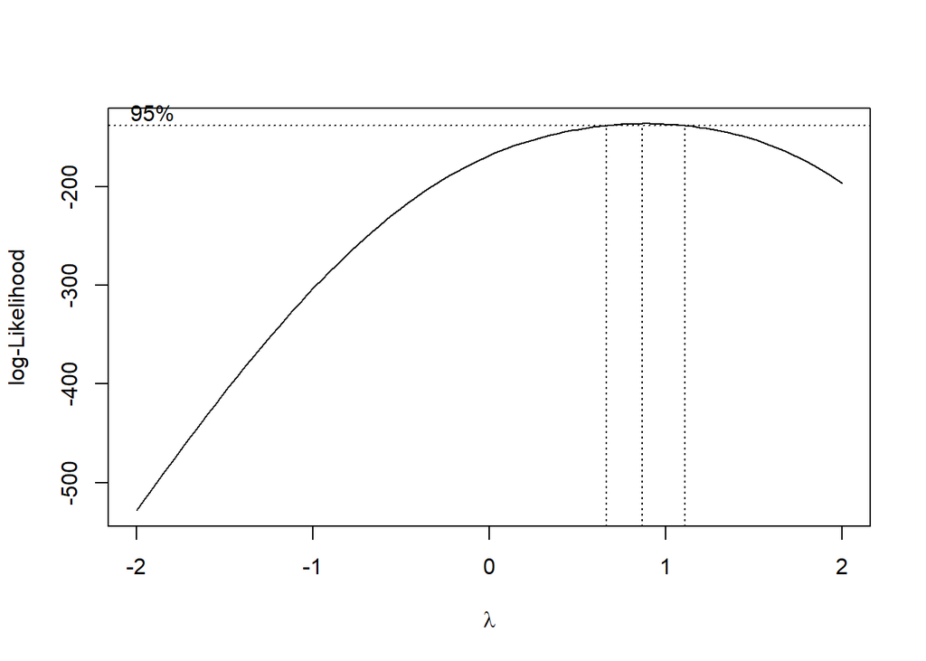

```r
### Aplicação da transformação de Box-Cox
mod <- aov(y ~ bl + tr,
           data=dados)
library(MASS)
boxcox(mod)
```

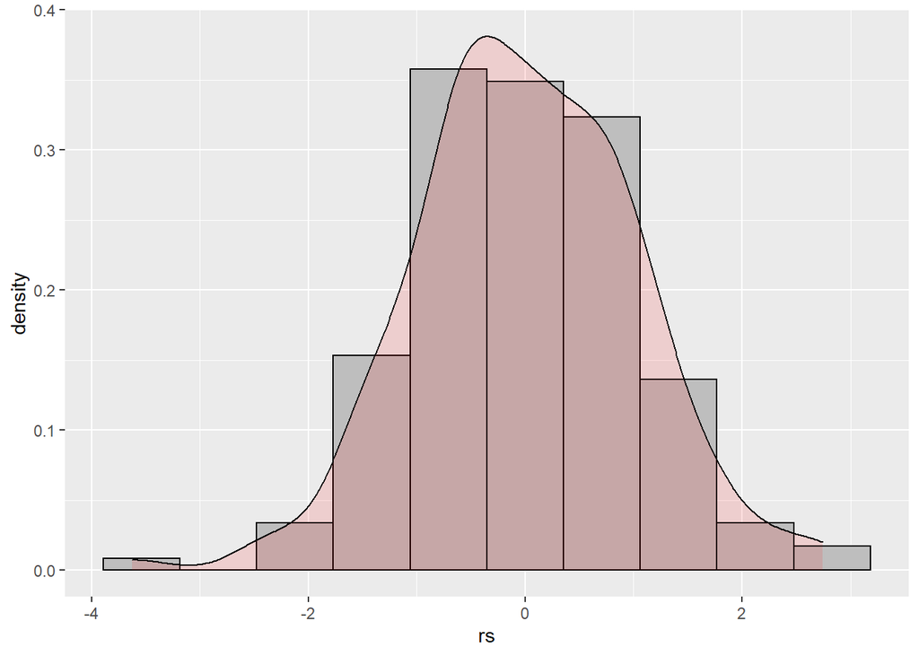

```r
## teste de normalidade dos resíduos
dados %>%
  drop_na() %>%
  mutate(
    rs = rstudent(aov(y ~ tr + bl))
  ) %>%
  ggplot(aes(x=rs, y=..density..)) +
  geom_histogram(bins=10, color="black",fill="gray") +
  geom_density(fill="red", alpha=.12)
```

```r
# Extraindo os resíduos
rs <- dados %>%
  drop_na() %>%
  mutate(
    rs = rstudent(aov(y ~ bl + tr))
  ) %>% pull(rs)
shapiro.test(rs)
```

```
##
##  Shapiro-Wilk normality test
##
## data:  rs
## W = 0.99217, p-value = 0.5056
```

```r
library(nortest)
ad.test(rs)
```

```
##
##  Anderson-Darling normality test
##
## data:  rs
## A = 0.28753, p-value = 0.616
```

```r
cvm.test(rs)
```

```
##
##  Cramer-von Mises normality test
##
## data:  rs
## W = 0.041263, p-value = 0.6562
```

```r
lillie.test(rs)
```

```
##
##  Lilliefors (Kolmogorov-Smirnov) normality test
##
## data:  rs
## D = 0.057024, p-value = 0.2077
```

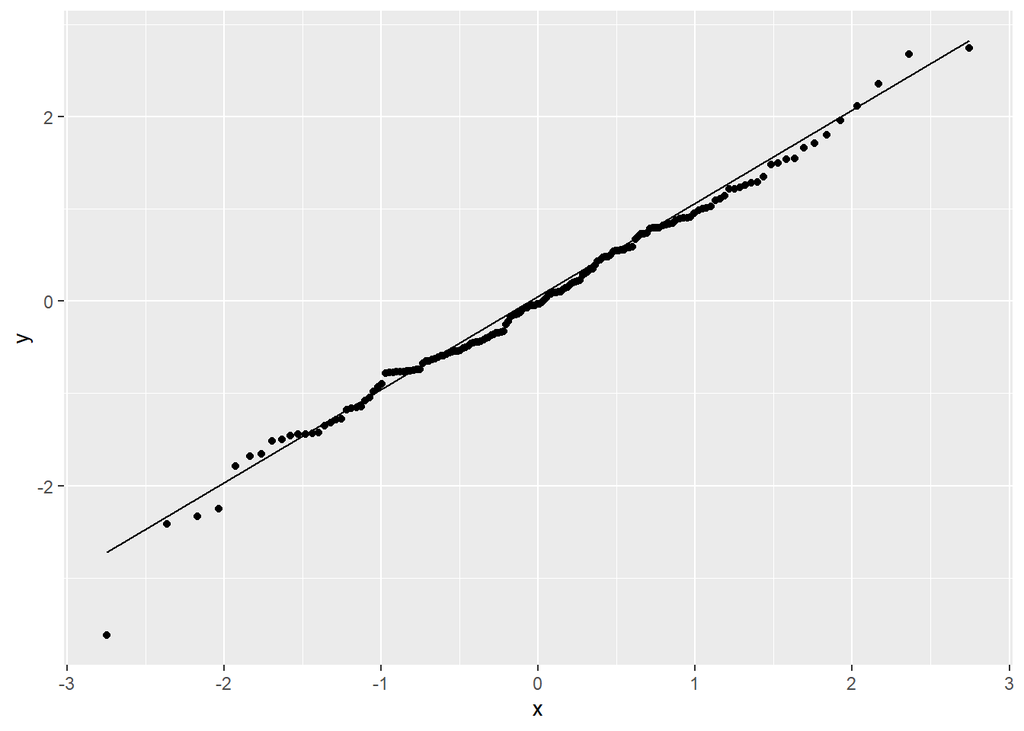

```r
## construir o qqplot
dados %>%
  drop_na() %>%
  mutate(
    rs = rstudent(aov(y ~ bl + tr))
  ) %>%
  ggplot(aes(sample = rs)) +
  stat_qq() +
  stat_qq_line()
```

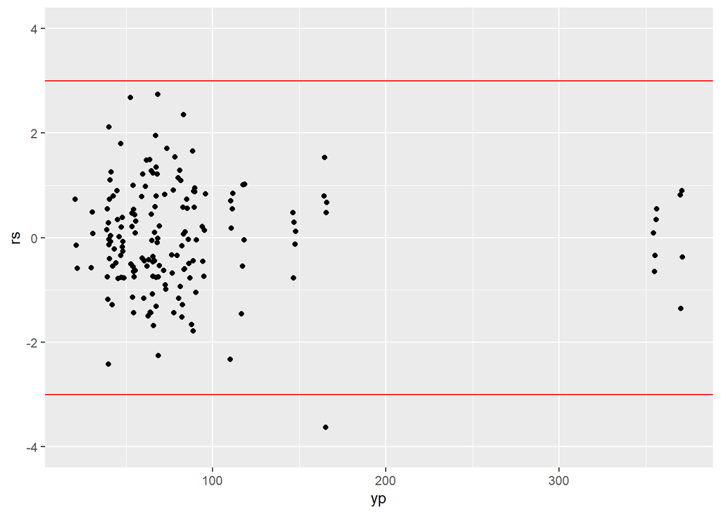

```r
# Estudo dos outliers
dados %>%
  drop_na() %>%
  mutate(
    rs = aov(y ~ tr + bl) %>% rstudent,
    yp = aov(y ~ tr + bl) %>% predict()
  ) %>%
  ggplot(aes(x=yp,y=rs)) +
  geom_point() +
  coord_cartesian(ylim=c(-4,4)) +
  geom_hline(yintercept = c(-3,3), color="red")
```

```r
## identificando os outliers

dados <- dados %>%
  drop_na() %>%
  mutate(
    rs = aov(z ~ tr + bl) %>% rstudent,
    yp = aov(z ~ tr + bl) %>% predict()
  ) %>%
  mutate(
    y2 = ifelse(rs < -3 | rs > 3, yp, z)
  )

## Análise de variância
mod <- aov(y ~ bl + cultivar*cigarrinha,
           data = dados)
anova(mod)
```

```
## Analysis of Variance Table
##
## Response: y
##                      Df Sum Sq Mean Sq  F value    Pr(>F)
## bl                    1     11      11   0.0535    0.8175
## cultivar             17 805312   47371 236.0813 < 2.2e-16 ***
## cigarrinha            1  33001   33001 164.4662 < 2.2e-16 ***
## cultivar:cigarrinha  16  22273    1392   6.9375 2.773e-11 ***
## Residuals           130  26085     201
## ---
## Signif. codes:  0 '***' 0.001 '**' 0.01 '*' 0.05 '.' 0.1 ' ' 1
```